# Homework 5 2018 - ANSWER KEY

Melinda Higgins

03/31/2018

Download the dataset from the Canvas folder. Then let’s load everything in:

```r
# Load all packages
library(phyloseq)
packageVersion("phyloseq")
```

```
## [1] '1.22.3'
```

```r
library(ggplot2)
packageVersion("ggplot2")
```

```
## [1] '2.2.1'
```

```r
library(RColorBrewer)
packageVersion("RColorBrewer")
```

```
## [1] '1.1.2'
```

```r
#Load HMP data
#You will need to download the data from Canvas
# You will need to change your path

load("HMPv35.RData")

# list summary of data components
# within the HMPv35 dataset
HMPv35
```

```
## phyloseq-class experiment-level object
## otu_table()   OTU Table:         [ 45336 taxa and 4743 samples ]
## sample_data() Sample Data:       [ 4743 samples by 9 sample variables ]
## tax_table()   Taxonomy Table:    [ 45336 taxa by 6 taxonomic ranks ]
## phy_tree()    Phylogenetic Tree: [ 45336 tips and 45099 internal nodes ]
## refseq()      DNAStringSet:      [ 45336 reference sequences ]
```

What is in here?

```r
summary(sample_data(HMPv35))
```

```
##    X.SampleID             RSID              visitno         sex
##  Min.   :700013549   Min.   :132902142   Min.   :1.00   female:2188
##  1st Qu.:700033710   1st Qu.:159611913   1st Qu.:1.00   male  :2555
##  Median :700097914   Median :161270782   Median :1.00
##  Mean   :700074251   Mean   :392105561   Mean   :1.41
##  3rd Qu.:700106406   3rd Qu.:763678604   3rd Qu.:2.00
##  Max.   :700114750   Max.   :970836795   Max.   :3.00
##
##      RUNCENTER                         HMPbodysubsite Mislabeled
##  WUGC     :1539   Stool                       : 319   Mode :logical
##  BI       :1078   Tongue_dorsum               : 316   FALSE:3730
##  JCVI     :1009   Attached_Keratinized_gingiva: 313   NA's :1013
##  BCM      : 696   Supragingival_plaque        : 313
##  BCM,BI   : 103   Buccal_mucosa               : 312
##  JCVI,WUGC:  93   Palatine_Tonsils            : 312
##  (Other)  : 225   (Other)                     :2858
##  Contaminated
##  Mode :logical
##  FALSE:3730
##  NA's :1013
##
##
##
##
##                                                                     Description
##  HMP_Human_metagenome_sample_700013549_from_subject_158013734__sex_female_:   1
##  HMP_Human_metagenome_sample_700014386_from_subject_158398106__sex_male_  :   1
##  HMP_Human_metagenome_sample_700014403_from_subject_158398106__sex_male_  :   1
##  HMP_Human_metagenome_sample_700014409_from_subject_158398106__sex_male_  :   1
##  HMP_Human_metagenome_sample_700014412_from_subject_158398106__sex_male_  :   1
##  HMP_Human_metagenome_sample_700014415_from_subject_158398106__sex_male_  :   1
##  (Other)                                                                  :4737
```

Let’s subset to get only samples from Stool or Palatine_Tonsils.

```r
#Subset
sub <- get_variable(HMPv35, "HMPbodysubsite") %in% c("Stool", "Palatine_Tonsils")

sample_data(HMPv35)$sub <- factor(sub)

HMPv35sub <- prune_samples(sample_data(HMPv35)$sub == TRUE, HMPv35)

summary(sample_data(HMPv35sub))
```

```
##    X.SampleID             RSID              visitno         sex
##  Min.   :700013549   Min.   :147406386   Min.   :1.00   female:263
##  1st Qu.:700033546   1st Qu.:159601798   1st Qu.:1.00   male  :368
##  Median :700097764   Median :161311242   Median :1.00
##  Mean   :700074025   Mean   :394173873   Mean   :1.41
##  3rd Qu.:700106408   3rd Qu.:763678604   3rd Qu.:2.00
##  Max.   :700114750   Max.   :970836795   Max.   :3.00
##
##      RUNCENTER            HMPbodysubsite Mislabeled      Contaminated
##  WUGC     :209   Palatine_Tonsils:312    Mode :logical   Mode :logical
##  BI       :139   Stool           :319    FALSE:489       FALSE:489
##  JCVI     :134                           NA's :142       NA's :142
##  BCM      : 90
##  JCVI,WUGC: 12
##  BCM,BI   : 11
##  (Other)  : 36
##                                                                     Description
##  HMP_Human_metagenome_sample_700013549_from_subject_158013734__sex_female_:  1
##  HMP_Human_metagenome_sample_700014386_from_subject_158398106__sex_male_  :  1
##  HMP_Human_metagenome_sample_700014421_from_subject_158398106__sex_male_  :  1
##  HMP_Human_metagenome_sample_700014488_from_subject_158438567__sex_male_  :  1
##  HMP_Human_metagenome_sample_700014497_from_subject_158418336__sex_male_  :  1
##  HMP_Human_metagenome_sample_700014519_from_subject_158418336__sex_male_  :  1
##  (Other)                                                                  :625
##    sub
##  TRUE:631
##
##
##
##
##
##
```

```r
HMPv35sub
```

```
## phyloseq-class experiment-level object
## otu_table()   OTU Table:         [ 45336 taxa and 631 samples ]
## sample_data() Sample Data:       [ 631 samples by 10 sample variables ]
## tax_table()   Taxonomy Table:    [ 45336 taxa by 6 taxonomic ranks ]
## phy_tree()    Phylogenetic Tree: [ 45336 tips and 45099 internal nodes ]
## refseq()      DNAStringSet:      [ 45336 reference sequences ]
```

#### Problem 1

Subset the HMPv35 object to obtain only the samples from Tongue_dorsum. Call this new object HMPv35sub2

```r
# Fill in your code to subset
# Call the new object HMPv35sub2

#Subset
sub <- get_variable(HMPv35, "HMPbodysubsite") %in% c("Tongue_dorsum")

sample_data(HMPv35)$sub <- factor(sub)

HMPv35sub2 <- prune_samples(sample_data(HMPv35)$sub == TRUE, HMPv35)

summary(sample_data(HMPv35sub2))
```

```
##    X.SampleID             RSID              visitno          sex
##  Min.   :700014409   Min.   :132902142   Min.   :1.000   female:132
##  1st Qu.:700033504   1st Qu.:159586626   1st Qu.:1.000   male  :184
##  Median :700097802   Median :161250552   Median :1.000
##  Mean   :700074079   Mean   :389803522   Mean   :1.415
##  3rd Qu.:700106136   3rd Qu.:763638144   3rd Qu.:2.000
##  Max.   :700114709   Max.   :970836795   Max.   :3.000
##
##     RUNCENTER         HMPbodysubsite Mislabeled      Contaminated
##  WUGC    :103   Tongue_dorsum:316    Mode :logical   Mode :logical
##  BI      : 68                        FALSE:245       FALSE:245
##  JCVI    : 64                        NA's :71        NA's :71
##  BCM     : 44
##  BCM,BI  : 11
##  BCM,JCVI:  7
##  (Other) : 19
##                                                                     Description
##  HMP_Human_metagenome_sample_700014409_from_subject_158398106__sex_male_  :  1
##  HMP_Human_metagenome_sample_700014515_from_subject_158418336__sex_male_  :  1
##  HMP_Human_metagenome_sample_700014609_from_subject_158438567__sex_male_  :  1
##  HMP_Human_metagenome_sample_700014731_from_subject_158458797__sex_female_:  1
##  HMP_Human_metagenome_sample_700014785_from_subject_158479027__sex_male_  :  1
##  HMP_Human_metagenome_sample_700014911_from_subject_158499257__sex_male_  :  1
##  (Other)                                                                  :310
##    sub
##  TRUE:316
##
##
##
##
##
##
```

```r
HMPv35sub2
```

```
## phyloseq-class experiment-level object
## otu_table()   OTU Table:         [ 45336 taxa and 316 samples ]
## sample_data() Sample Data:       [ 316 samples by 10 sample variables ]
## tax_table()   Taxonomy Table:    [ 45336 taxa by 6 taxonomic ranks ]
## phy_tree()    Phylogenetic Tree: [ 45336 tips and 45099 internal nodes ]
## refseq()      DNAStringSet:      [ 45336 reference sequences ]
```

Let’s look at diversity

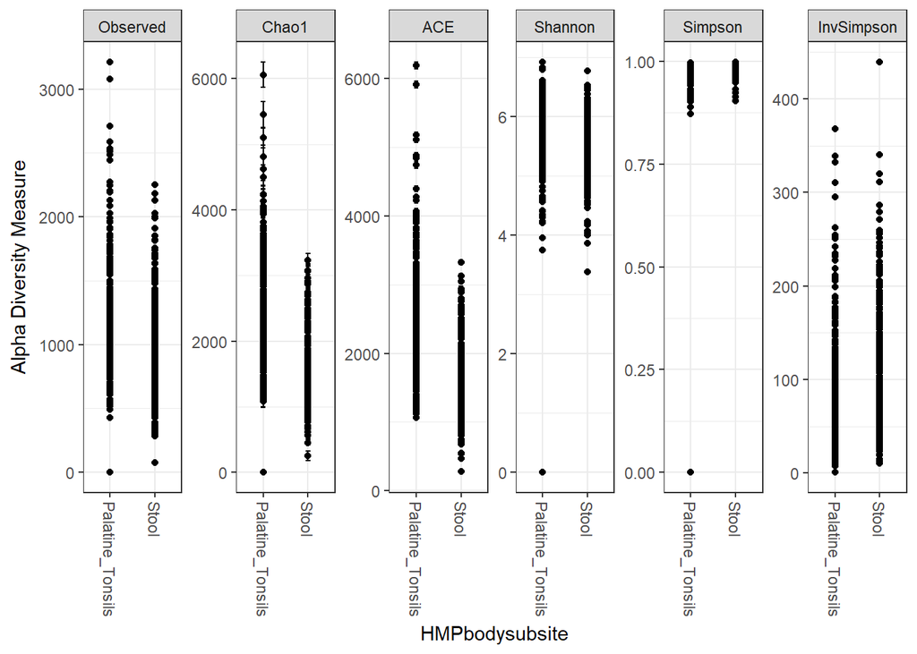

```r
#This changes the background to my favorite
theme_set(theme_bw())

#The following commands plot the different diversity measures for the two different body sites.
alpha_meas = c("Observed", "Chao1", "ACE", "Shannon", "Simpson", "InvSimpson")
(p <- plot_richness(HMPv35sub, "HMPbodysubsite", measures=alpha_meas))
```

Let’s add a box plot to these displays of diversity

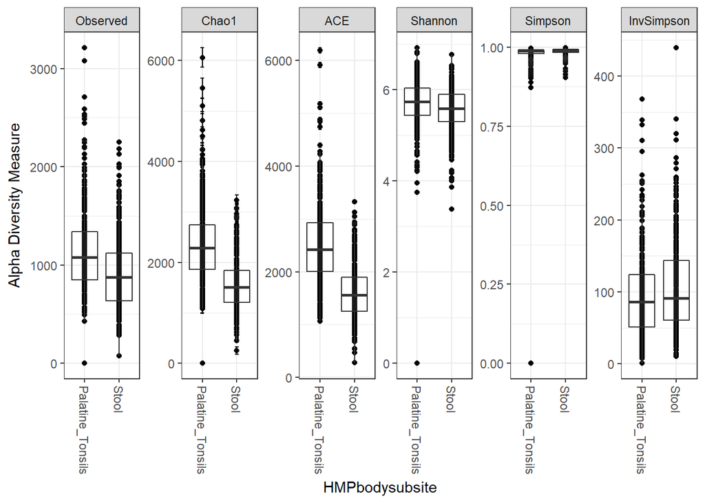

```r
p + geom_boxplot(data=p$data, aes(x=HMPbodysubsite, y=value, color=NULL), alpha=0.1)
```

#### Problem 2

Produce the geometric box plot of diversity measures for your object, HMPv35sub2

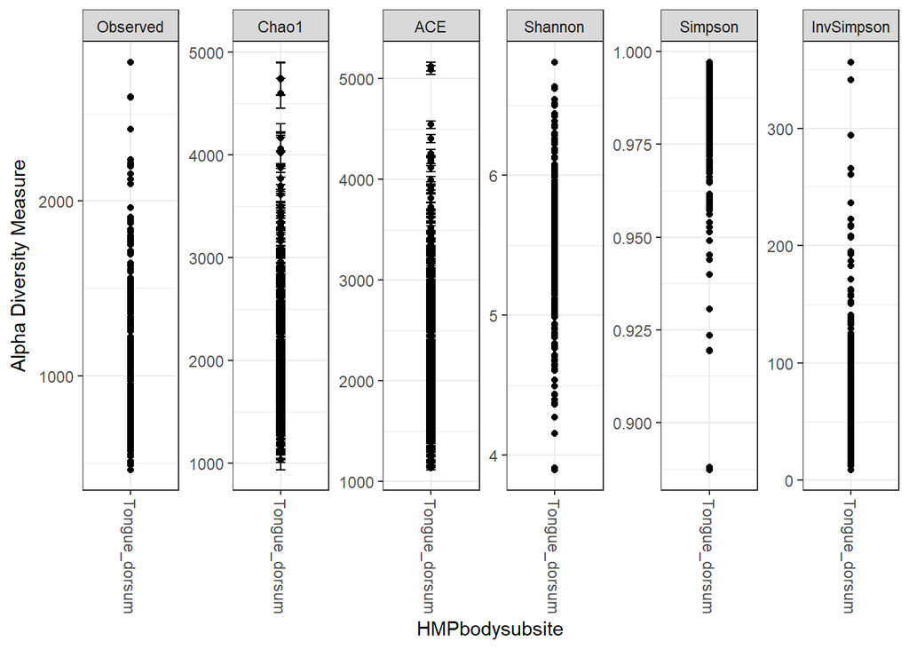

```r
#Place your code for the box plot for diversity here

#This changes the background to my favorite
theme_set(theme_bw())

#The following commands plot the different diversity measures for the Tongue_dorsum body site.
alpha_meas = c("Observed", "Chao1", "ACE", "Shannon", "Simpson", "InvSimpson")
(p <- plot_richness(HMPv35sub2, "HMPbodysubsite", measures=alpha_meas))
```

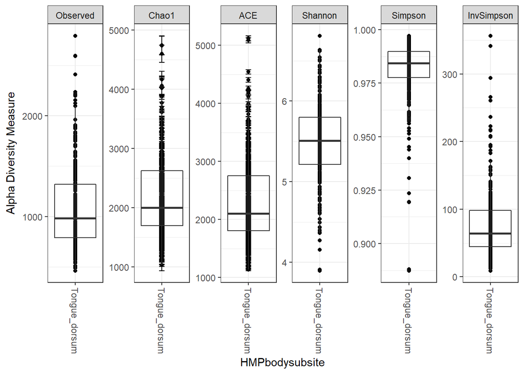

```r
p + geom_boxplot(data=p$data, aes(x=HMPbodysubsite, y=value, color=NULL), alpha=0.1)
```

Let’s see what phyla are represented here. This will rely on Base R graphics.

```r
#Calclate number of taxa in object
ntaxa(HMPv35sub)
```

```
## [1] 45336
```

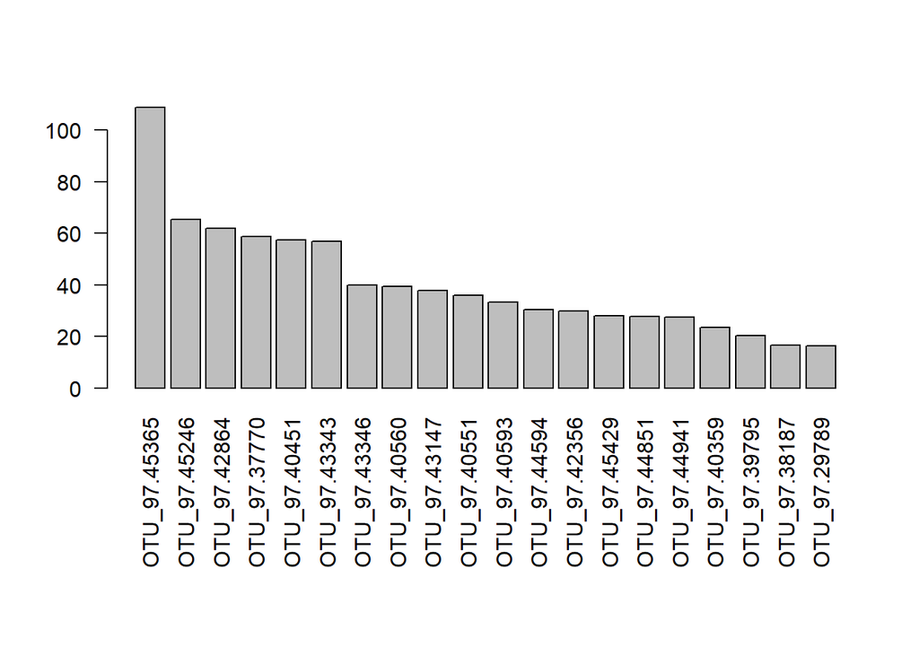

```r
par(mar = c(10, 4, 4, 2) + 0.1) # make more room on bottom margin
N <- 20
barplot(sort(taxa_sums(HMPv35sub), TRUE)[1:N]/nsamples(HMPv35sub), las=2)
```

Since there are over 45000 taxa represented in this object, we are only going for the top 20.

#### Problem 3

You see what taxa are most prevalent in your subset, HMPv35sub2

```r
#Place your code here

#Calclate number of taxa in object
ntaxa(HMPv35sub2)
```

```
## [1] 45336
```

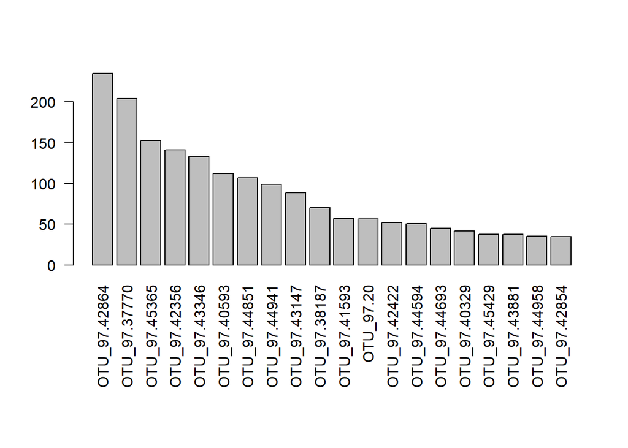

```r
par(mar = c(10, 4, 4, 2) + 0.1) # make more room on bottom margin
N <- 20
barplot(sort(taxa_sums(HMPv35sub2), TRUE)[1:N]/nsamples(HMPv35sub2), las=2)
```

Let’s filter OTU’s a bit, throwing out rare taxa.

```r
#The next step filters out taxa with low occurrence throughout all samples

HMPv35subsub = filter_taxa(HMPv35sub, function(x) sum(x > 3) > (0.2*length(x)), TRUE)

# The next step filters out all taxa that occur in less than .01% of samples

HMPv35subr  <- transform_sample_counts(HMPv35subsub, function(x) x / sum(x) )
HMPv35subfr <- filter_taxa(HMPv35subr, function(x) mean(x) > 1e-5, TRUE)

HMPv35subfr
```

```
## phyloseq-class experiment-level object
## otu_table()   OTU Table:         [ 131 taxa and 631 samples ]
## sample_data() Sample Data:       [ 631 samples by 10 sample variables ]
## tax_table()   Taxonomy Table:    [ 131 taxa by 6 taxonomic ranks ]
## phy_tree()    Phylogenetic Tree: [ 131 tips and 130 internal nodes ]
## refseq()      DNAStringSet:      [ 131 reference sequences ]
```

```r
#Finally subset to only bacteria in the phylum Bacteroidetes

HMPv35subfrbac = subset_taxa(HMPv35subfr, Phylum=="Bacteroidetes")
HMPv35subfrbac
```

```
## phyloseq-class experiment-level object
## otu_table()   OTU Table:         [ 62 taxa and 631 samples ]
## sample_data() Sample Data:       [ 631 samples by 10 sample variables ]
## tax_table()   Taxonomy Table:    [ 62 taxa by 6 taxonomic ranks ]
## phy_tree()    Phylogenetic Tree: [ 62 tips and 61 internal nodes ]
## refseq()      DNAStringSet:      [ 62 reference sequences ]
```

So we have gone from 45336 taxa in 4743 in the original HMPv35 dataset

to 45336 taxa in 631 samples in the Stool and Palatine Tonsil samples subset

to 131 taxa in 631 samples after the two filtering steps

to 62 taxa in the phylum Bacteroidetes in 631 samples.

#### Problem 4

Using your HMPv35sub2 object, throw the rare taxa out of that object, then reduce to only taxa in the phylum Bacteroidetes. Call this new object HMPv35sub2frbac

```r
#Insert your code to throw out the rare taxa from the HMPv35sub2 object

#Call the object HMPv35sub2frbac

#The next step filters out taxa with low occurrence throughout all samples

HMPv35subsub2 = filter_taxa(HMPv35sub2, function(x) sum(x > 3) > (0.2*length(x)), TRUE)

# The next step filters out all taxa that occur in less than .01% of samples

HMPv35subr2  <- transform_sample_counts(HMPv35subsub2, function(x) x / sum(x) )
HMPv35subfr2 <- filter_taxa(HMPv35subr2, function(x) mean(x) > 1e-5, TRUE)

HMPv35subfr2
```

```
## phyloseq-class experiment-level object
## otu_table()   OTU Table:         [ 307 taxa and 316 samples ]
## sample_data() Sample Data:       [ 316 samples by 10 sample variables ]
## tax_table()   Taxonomy Table:    [ 307 taxa by 6 taxonomic ranks ]
## phy_tree()    Phylogenetic Tree: [ 307 tips and 304 internal nodes ]
## refseq()      DNAStringSet:      [ 307 reference sequences ]
```

```r
#Finally subset to only bacteria in the phylum Bacteroidetes

HMPv35subfrbac2 = subset_taxa(HMPv35subfr2, Phylum=="Bacteroidetes")
HMPv35subfrbac2
```

```
## phyloseq-class experiment-level object
## otu_table()   OTU Table:         [ 46 taxa and 316 samples ]
## sample_data() Sample Data:       [ 316 samples by 10 sample variables ]
## tax_table()   Taxonomy Table:    [ 46 taxa by 6 taxonomic ranks ]
## phy_tree()    Phylogenetic Tree: [ 46 tips and 45 internal nodes ]
## refseq()      DNAStringSet:      [ 46 reference sequences ]
```

Let’s look at the top taxa again in this filtered object.

```r
#Calclate number of taxa in object
ntaxa(HMPv35subfrbac)
```

```
## [1] 62
```

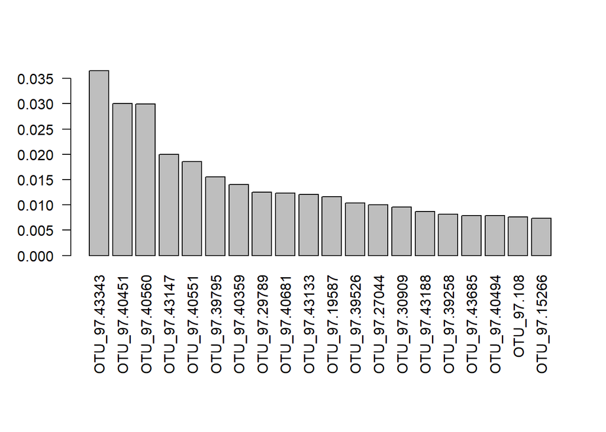

```r
par(mar = c(10, 4, 4, 2) + 0.1) # make more room on bottom margin
N <- 20
barplot(sort(taxa_sums(HMPv35subfrbac), TRUE)[1:N]/nsamples(HMPv35subfrbac), las=2)
```

#### Problem 5

Using your HMPv35sub2frbac object, what is the distribution of the top 20 OTU’s?

```r
#Place your code here.

#Calclate number of taxa in object
ntaxa(HMPv35subfrbac2)
```

```
## [1] 46
```

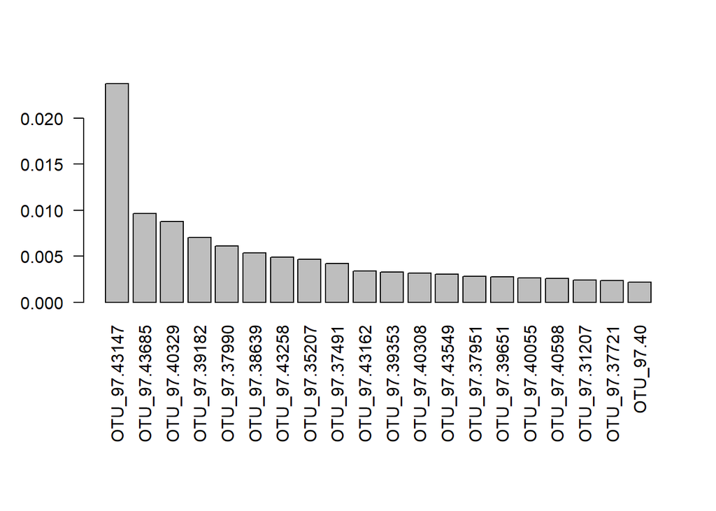

```r
par(mar = c(10, 4, 4, 2) + 0.1) # make more room on bottom margin
N <- 20
barplot(sort(taxa_sums(HMPv35subfrbac2), TRUE)[1:N]/nsamples(HMPv35subfrbac2), las=2)
```

Now let’s summarize this slice of data with some more graphics

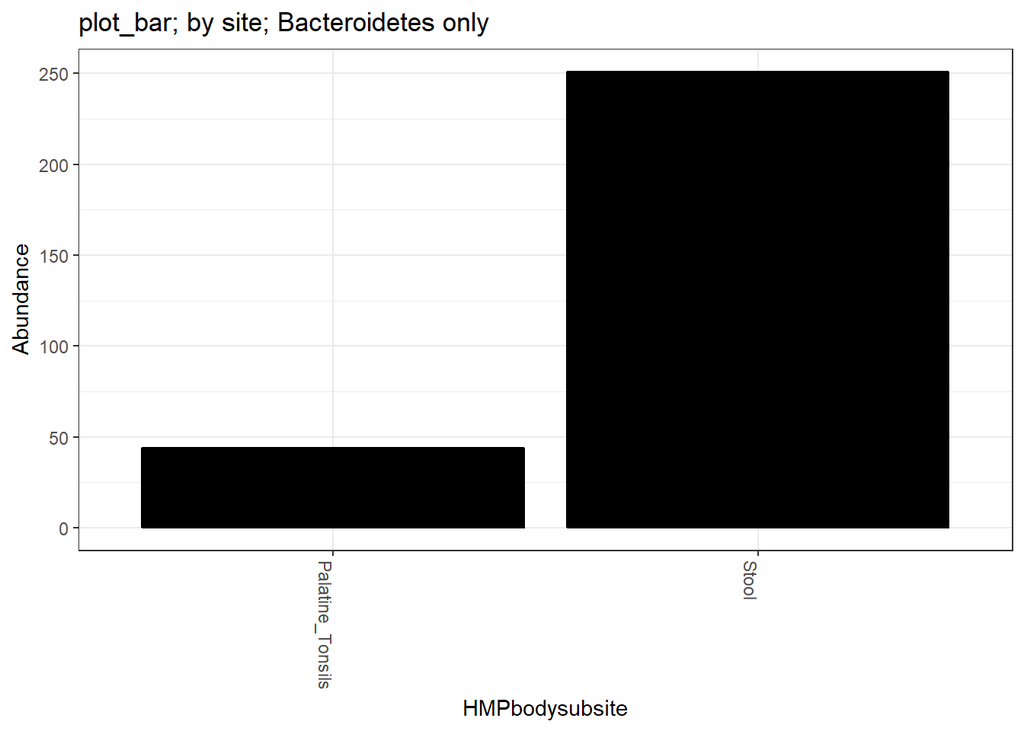

```r
title = "plot_bar; by site; Bacteroidetes only"
plot_bar(HMPv35subfrbac, "HMPbodysubsite", "Abundance", title=title)
```

#### Problem 6

Plot sample abundance by body site for your object HMPv35sub2frbac

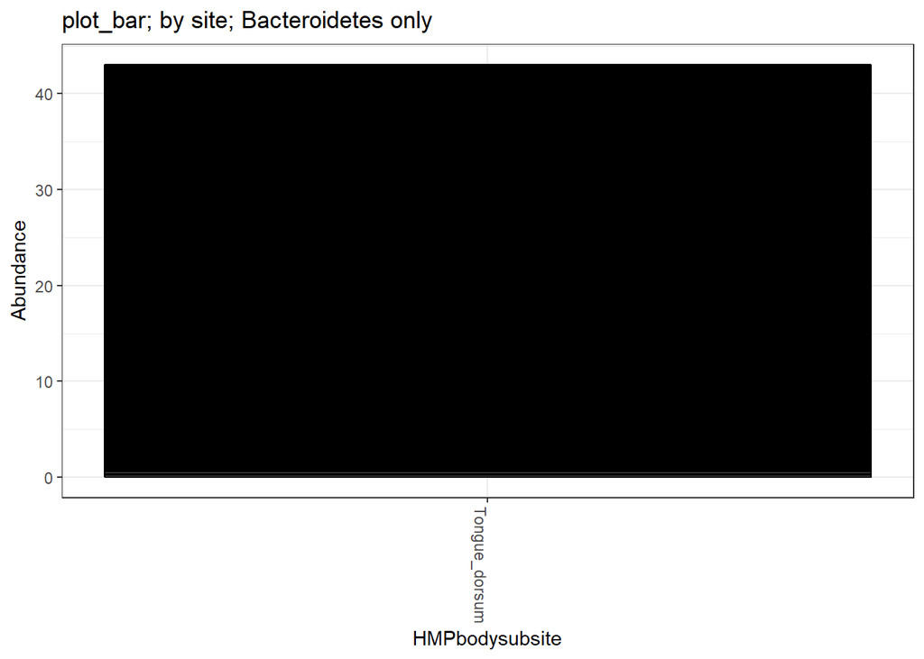

```r
#Place your code for the plat here
title = "plot_bar; by site; Bacteroidetes only"
plot_bar(HMPv35subfrbac2, "HMPbodysubsite", "Abundance", title=title)
```

Let’s try to see if there is something more to differentiate here beyond the black blobs.

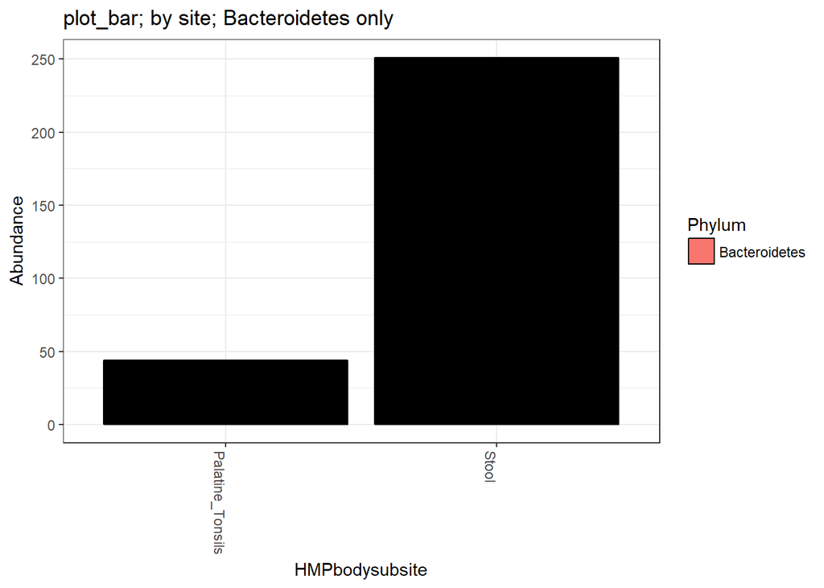

```r
plot_bar(HMPv35subfrbac, "HMPbodysubsite", "Abundance", "Phylum", title=title)
```

#### Problem 7

You try it with your HMPv35sub2frbac object

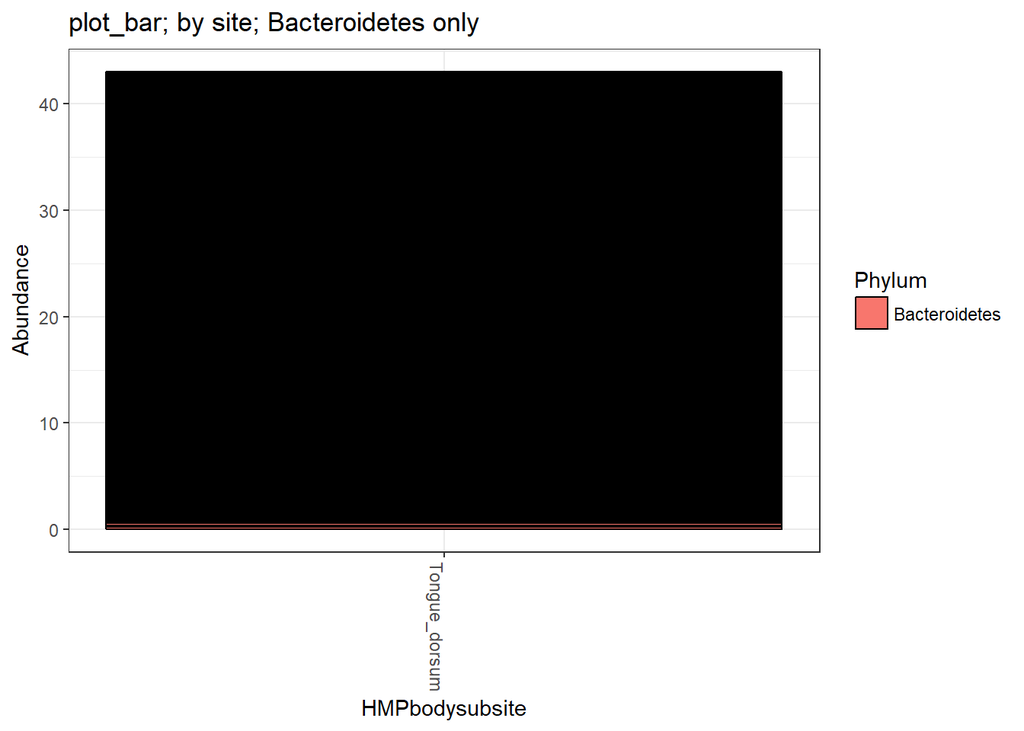

```r
#Place your code for your plot with family here
plot_bar(HMPv35subfrbac2, "HMPbodysubsite", "Abundance", "Phylum", title=title)
```

We can use the techniques of network science to illustrate how similar or distant samples are.

Using our filtered object with all phyla, we use the `plot_net` function to illustrate the “proximity” (or similarity) of samples, while denoting site and the sex of the participant.

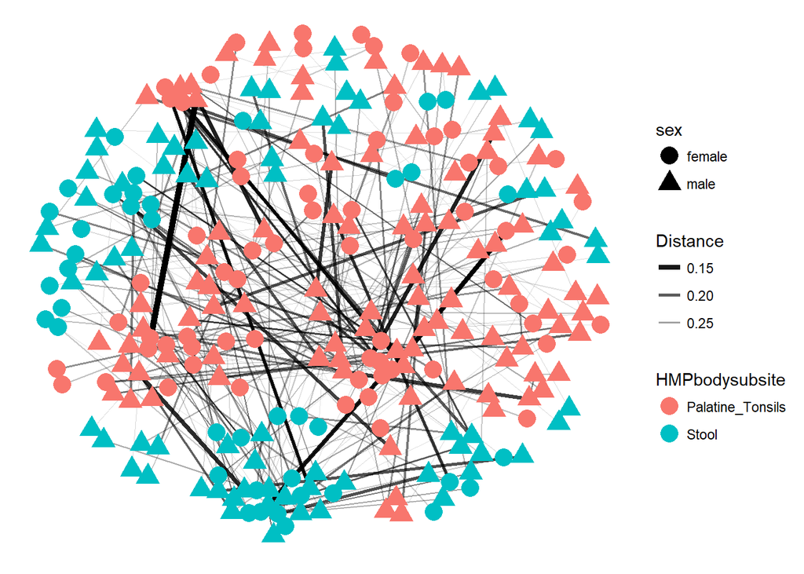

```r
plot_net(HMPv35subfr, maxdist = 0.3, color = "HMPbodysubsite", shape="sex")
```

Let’s redo switching which variable is colored and which variable is differentiated by shape.

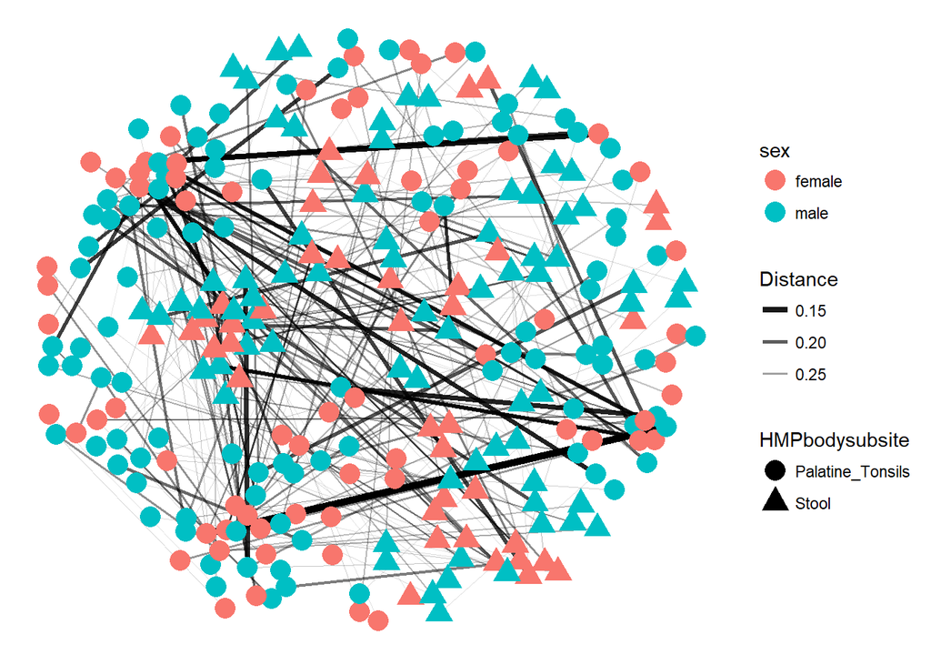

```r
plot_net(HMPv35subfr, maxdist = 0.3, shape = "HMPbodysubsite", color="sex")
```

#### Problem 8

Which method of display do you like best and why?

NOTE: Answers here may vary. I (Melinda) like the coloring by SEX and shapes by body type - but it depends on what you’re trying to illustrate by the figure. It could easily go the other way. The colors by Body Site do show the clusters more clearly. Here are the answers for both.

In this case, since we only have 1 body site (Tongue_dorsum) - it is probably more interesting to color code by sex.

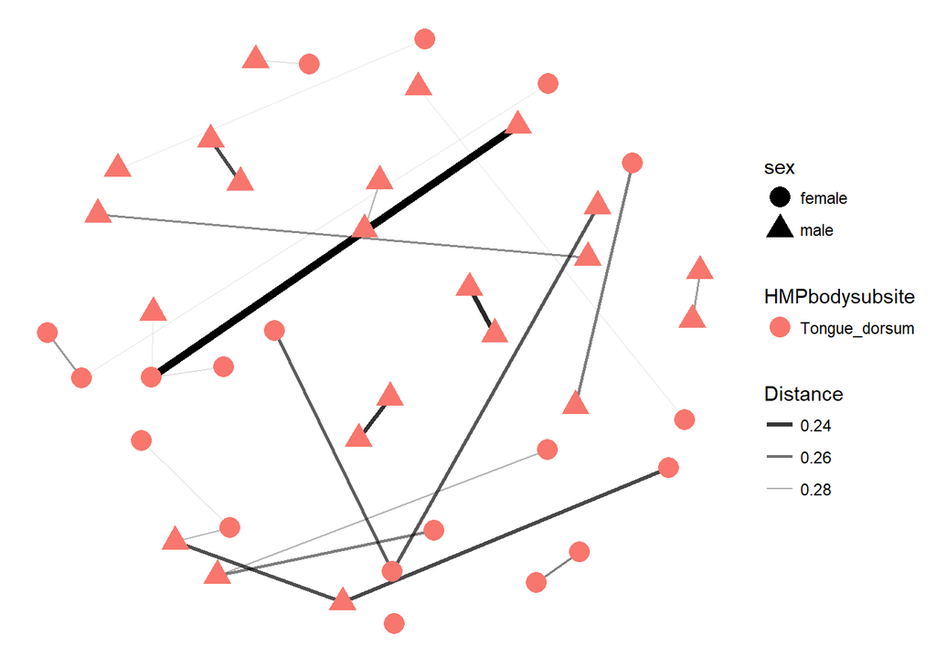

```r
#Place your answer here as another comment.

plot_net(HMPv35subfr2, maxdist = 0.3, color = "HMPbodysubsite", shape="sex")
```

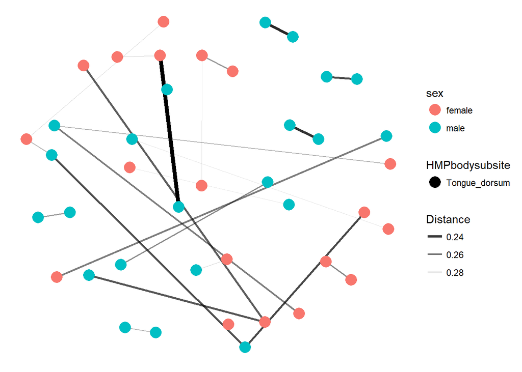

```r
plot_net(HMPv35subfr2, maxdist = 0.3, shape = "HMPbodysubsite", color="sex")
```